# Update

Kyle W. Brown

4/12/2020

## Update for Final Project

Providing update for final project. So, far this has a linear and expontential regression using the STATWORX COVID19 API. This is a public API and can be accessed very simply following the commands.

API link: https://github.com/STATWORX/covid-19-api

What’s completed here: - API stream and link to source to access for R and Python - GBM grid AutoML model and found some rather interested results in the cross-validation summary below. - Simple linear regression - Exponential regression found

What needs done: - Expontential regression from Michigan model, maybe adjusted to reflect US. - Started an exponential regression of US at the very bottom to see if plausible. - Research the effectiveness of each plot from the models. If demonstrate colinearity, overfitting, underfitting, etc it can be added to the dashboard and part of our story and analysis. Even though these visualizations maybe statistically irrelavent, we can still use it to explain the progression of the the linear regression analysis.

```r
library(httr)
library(jsonlite)
library(ggplot2)
library(ISLR)
# Post to API
payload <- list(code = "US")
response <- httr::POST(url = "https://api.statworx.com/covid",
                       body = toJSON(payload, auto_unbox = TRUE), encode = "json")

# Convert to data frame
content <- rawToChar(response$content)
us <- data.frame(fromJSON(content))
str(us)
```

```
## 'data.frame':    104 obs. of  11 variables:
##  $ date      : Factor w/ 104 levels "2019-12-31","2020-01-01",..: 1 2 3 4 5 6 7 8 9 10 ...
##  $ day       : int  31 1 2 3 4 5 6 7 8 9 ...
##  $ month     : int  12 1 1 1 1 1 1 1 1 1 ...
##  $ year      : int  2019 2020 2020 2020 2020 2020 2020 2020 2020 2020 ...
##  $ cases     : int  0 0 0 0 0 0 0 0 0 0 ...
##  $ deaths    : int  0 0 0 0 0 0 0 0 0 0 ...
##  $ country   : Factor w/ 1 level "United_States_of_America": 1 1 1 1 1 1 1 1 1 1 ...
##  $ code      : Factor w/ 1 level "US": 1 1 1 1 1 1 1 1 1 1 ...
##  $ population: int  327167434 327167434 327167434 327167434 327167434 327167434 327167434 327167434 327167434 327167434 ...
##  $ cases_cum : int  0 0 0 0 0 0 0 0 0 0 ...
##  $ deaths_cum: int  0 0 0 0 0 0 0 0 0 0 ...
```

```r
head(us)
```

```
##         date day month year cases deaths                  country code
## 1 2019-12-31  31    12 2019     0      0 United_States_of_America   US
## 2 2020-01-01   1     1 2020     0      0 United_States_of_America   US
## 3 2020-01-02   2     1 2020     0      0 United_States_of_America   US
## 4 2020-01-03   3     1 2020     0      0 United_States_of_America   US
## 5 2020-01-04   4     1 2020     0      0 United_States_of_America   US
## 6 2020-01-05   5     1 2020     0      0 United_States_of_America   US
##   population cases_cum deaths_cum
## 1  327167434         0          0
## 2  327167434         0          0
## 3  327167434         0          0
## 4  327167434         0          0
## 5  327167434         0          0
## 6  327167434         0          0
```

```r
# Post to API
payload <- list(code = "ALL")
response <- httr::POST(url = "https://api.statworx.com/covid",
                       body = toJSON(payload, auto_unbox = TRUE), encode = "json")

# Convert to data frame
content <- rawToChar(response$content)
world <- data.frame(fromJSON(content))

head(world)
```

```
##         date day month year cases deaths     country code population cases_cum
## 1 2019-12-31  31    12 2019     0      0 Afghanistan   AF   37172386         0
## 2 2020-01-01   1     1 2020     0      0 Afghanistan   AF   37172386         0
## 3 2020-01-02   2     1 2020     0      0 Afghanistan   AF   37172386         0
## 4 2020-01-03   3     1 2020     0      0 Afghanistan   AF   37172386         0
## 5 2020-01-04   4     1 2020     0      0 Afghanistan   AF   37172386         0
## 6 2020-01-05   5     1 2020     0      0 Afghanistan   AF   37172386         0
##   deaths_cum
## 1          0
## 2          0
## 3          0
## 4          0
## 5          0
## 6          0
```

# Linear Regressions

```r
attach(us)
model1 <- lm(cases_cum ~ deaths_cum)
model1
```

```
##
## Call:
## lm(formula = cases_cum ~ deaths_cum)
##
## Coefficients:
## (Intercept)   deaths_cum
##     7442.72        29.41
```

```r
summary(model1)
```

```
##
## Call:
## lm(formula = cases_cum ~ deaths_cum)
##
## Residuals:
##    Min     1Q Median     3Q    Max
## -83476  -7443  -7431  -6880  63963
##
## Coefficients:
##              Estimate Std. Error t value Pr(>|t|)
## (Intercept) 7442.7173  2395.0739   3.108  0.00244 **
## deaths_cum    29.4053     0.5623  52.296  < 2e-16 ***
## ---
## Signif. codes:  0 '***' 0.001 '**' 0.01 '*' 0.05 '.' 0.1 ' ' 1
##
## Residual standard error: 22970 on 102 degrees of freedom
## Multiple R-squared:  0.964,  Adjusted R-squared:  0.9637
## F-statistic:  2735 on 1 and 102 DF,  p-value: < 2.2e-16
```

```r
confint(model1)
```

```
##                  2.5 %      97.5 %
## (Intercept) 2692.09954 12193.33505
## deaths_cum    28.28999    30.52056
```

```r
predict(model1, data.frame(lstat=c(5,10,15)), interval = "confidence")
```

```
##            fit        lwr       upr
## 1     7442.717   2692.100  12193.34
## 2     7442.717   2692.100  12193.34
## 3     7442.717   2692.100  12193.34
## 4     7442.717   2692.100  12193.34
## 5     7442.717   2692.100  12193.34
## 6     7442.717   2692.100  12193.34
## 7     7442.717   2692.100  12193.34
## 8     7442.717   2692.100  12193.34
## 9     7442.717   2692.100  12193.34
## 10    7442.717   2692.100  12193.34
## 11    7442.717   2692.100  12193.34
## 12    7442.717   2692.100  12193.34
## 13    7442.717   2692.100  12193.34
## 14    7442.717   2692.100  12193.34
```

[output cut: 90 more lines]

```r
predict(model1, data.frame(lstat=c(5,10,15)), interval = "prediction")
```

```
##            fit         lwr       upr
## 1     7442.717 -38365.0078  53250.44
## 2     7442.717 -38365.0078  53250.44
## 3     7442.717 -38365.0078  53250.44
## 4     7442.717 -38365.0078  53250.44
## 5     7442.717 -38365.0078  53250.44
## 6     7442.717 -38365.0078  53250.44
## 7     7442.717 -38365.0078  53250.44
## 8     7442.717 -38365.0078  53250.44
## 9     7442.717 -38365.0078  53250.44
## 10    7442.717 -38365.0078  53250.44
## 11    7442.717 -38365.0078  53250.44
## 12    7442.717 -38365.0078  53250.44
## 13    7442.717 -38365.0078  53250.44
## 14    7442.717 -38365.0078  53250.44
```

[output cut: 90 more lines]

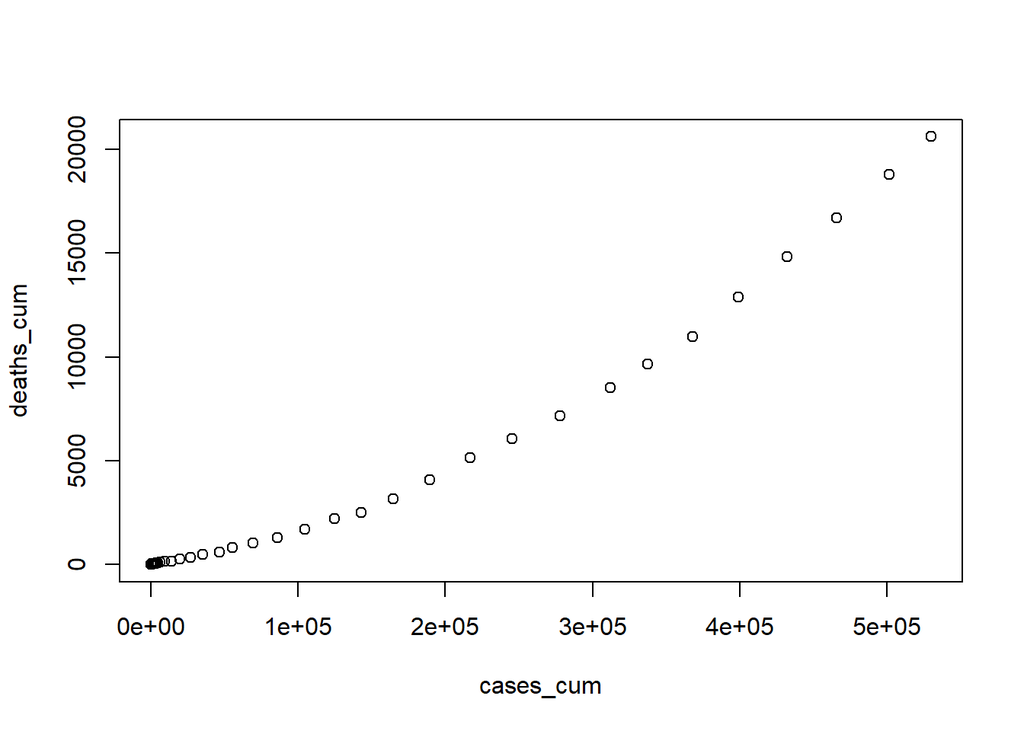

```r
plot(cases_cum, deaths_cum)
```

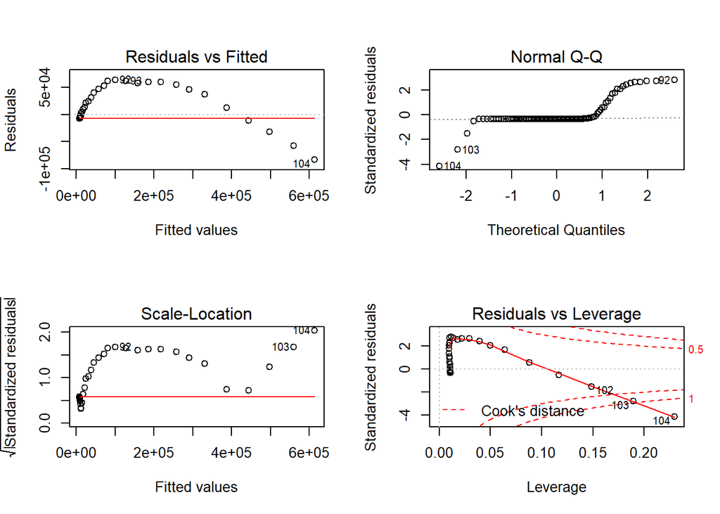

```r
par(mfrow = c(2,2))
plot(model1)
```

```r
model2 <- lm(deaths_cum ~ cases_cum)
model2
```

```
##
## Call:
## lm(formula = deaths_cum ~ cases_cum)
##
## Coefficients:
## (Intercept)    cases_cum
##  -191.93572      0.03278
```

```r
summary(model2)
```

```
##
## Call:
## lm(formula = deaths_cum ~ cases_cum)
##
## Residuals:
##     Min      1Q  Median      3Q     Max
## -2035.1   175.0   191.5   191.9  3425.6
##
## Coefficients:
##               Estimate Std. Error t value Pr(>|t|)
## (Intercept) -1.919e+02  8.149e+01  -2.355   0.0204 *
## cases_cum    3.278e-02  6.269e-04  52.296   <2e-16 ***
## ---
## Signif. codes:  0 '***' 0.001 '**' 0.01 '*' 0.05 '.' 0.1 ' ' 1
##
## Residual standard error: 767 on 102 degrees of freedom
## Multiple R-squared:  0.964,  Adjusted R-squared:  0.9637
## F-statistic:  2735 on 1 and 102 DF,  p-value: < 2.2e-16
```

```r
confint(model2)
```

```
##                    2.5 %       97.5 %
## (Intercept) -353.5628804 -30.30856500
## cases_cum      0.0315413   0.03402823
```

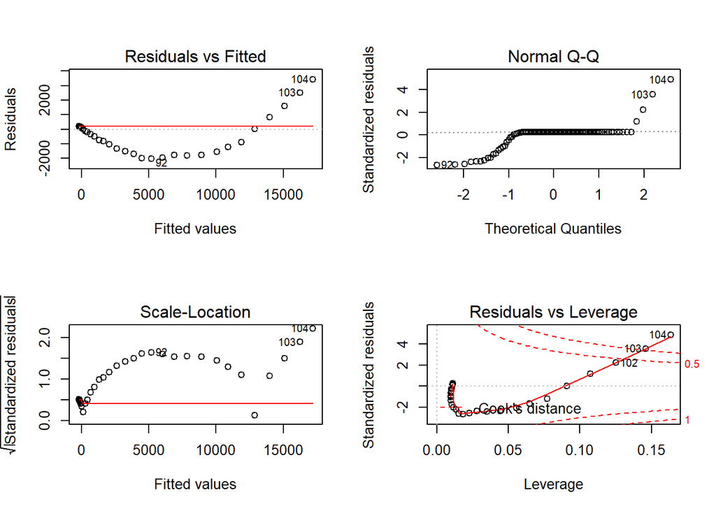

```r
par(mfrow = c(2,2))
plot(model2)
```

# AutoML using R

###Target = Cumulative Cases

```
#> automl_leader
```

```r
#Model Details:
#==============

#H2OMultinomialModel: gbm
#Model ID:  GBM_grid__1_AutoML_20200412_124540_model_23
#Model Summary:
#  number_of_trees number_of_internal_trees model_size_in_bytes min_depth max_depth mean_depth
#1              31                     1426              700966         1        12    7.73492
#  min_leaves max_leaves mean_leaves
#1          2         52    24.08906


#H2OMultinomialMetrics: gbm
#** Reported on cross-validation data. **
#** 5-fold cross-validation on training data (Metrics computed for combined holdout predictions) **

#Cross-Validation Set Metrics:
#=====================

#Extract cross-validation frame with `h2o.getFrame("automl_training_train")`
#MSE: (Extract with `h2o.mse`) 0.6775615
#RMSE: (Extract with `h2o.rmse`) 0.8231412
#Logloss: (Extract with `h2o.logloss`) 2.779394
#Mean Per-Class Error: 0.6803279
#R^2: (Extract with `h2o.r2`) 0.998153
#Hit Ratio Table: Extract with `h2o.hit_ratio_table(<model>,xval = TRUE)`
#=======================================================================
#Top-10 Hit Ratios:
#    k hit_ratio
#1   1  0.333333
#2   2  0.333333
#3   3  0.333333
#4   4  0.333333
#5   5  0.333333
#6   6  0.333333
#7   7  0.333333
#8   8  0.333333
#9   9  0.333333
#10 10  0.333333


#Cross-Validation Metrics Summary:
#                              mean           sd   cv_1_valid  cv_2_valid  cv_3_valid   cv_4_valid
#accuracy                0.33461538   0.10537027   0.46153846  0.23076923  0.23076923   0.41666666
#err                      0.6653846   0.10537027   0.53846157   0.7692308   0.7692308    0.5833333
#err_count                      8.4    1.5165751          7.0        10.0        10.0          7.0
#logloss                  2.7758408   0.34117955    2.3411372   3.2307265   2.9795272     2.624038
#max_per_class_error            1.0          0.0          1.0         1.0         1.0          1.0
#mean_per_class_accuracy  0.8622951  0.024861887    0.8852459   0.8360656   0.8360656    0.8852459
#mean_per_class_error    0.13770492  0.024861887  0.114754096  0.16393442  0.16393442  0.114754096
#mse                      0.6769041   0.07867551   0.56781155  0.76306975  0.74124897    0.6414364
#r2                       0.9980467  6.158894E-4   0.99866897   0.9981172   0.9970298      0.99807
#rmse                    0.82160884   0.04825612    0.7535327   0.8735386  0.86095816   0.80089724

#                        cv_5_valid
#accuracy                0.33333334
#err                      0.6666667
#err_count                      8.0
#logloss                  2.7037756
#max_per_class_error            1.0
#mean_per_class_accuracy 0.86885244
#mean_per_class_error    0.13114753
#mse                      0.6709537
#r2                      0.99834746
#rmse                     0.8191176
```

# Predicting Michigan COVID19

```r
# read data from a csv file
data = read.csv("https://raw.githubusercontent.com/nagdevAmruthnath/covid19-Michigan/master/covid19.csv", header = T)

# view data
head(data)
```

```
##        Date Day Cases Daily Previous Deaths
## 1 3/10/2020   1     2     2        0      0
## 2 3/11/2020   2     2     0        2      0
## 3 3/12/2020   3    12    10        0      0
## 4 3/13/2020   4    25    13       10      0
## 5 3/14/2020   5    33     8       13      0
## 6 3/15/2020   6    53    20        8      0
```

# Exponential Regression

```r
# create samples from the data
samples = sample(1:16, size = 16*0.8)

## Predict model based on cases and days

# build an exponential regression model
model = lm(log(Cases) ~ Day + I(Day^2) , data = data[samples,])

# look at the summary of the model
summary(model)
```

```
##
## Call:
## lm(formula = log(Cases) ~ Day + I(Day^2), data = data[samples,
##     ])
##
## Residuals:
##     Min      1Q  Median      3Q     Max
## -0.6331 -0.1193  0.0292  0.1714  0.6238
##
## Coefficients:
##              Estimate Std. Error t value Pr(>|t|)
## (Intercept) -0.057401   0.493519  -0.116 0.909961
## Day          0.720502   0.127805   5.637 0.000319 ***
## I(Day^2)    -0.014342   0.007035  -2.039 0.071911 .
## ---
## Signif. codes:  0 '***' 0.001 '**' 0.01 '*' 0.05 '.' 0.1 ' ' 1
##
## Residual standard error: 0.4211 on 9 degrees of freedom
## Multiple R-squared:  0.9719, Adjusted R-squared:  0.9656
## F-statistic: 155.5 on 2 and 9 DF,  p-value: 1.05e-07
```

## Summary note the author focused on the Adjusted R^2 at the accuracy prediction and noted that the model most likely was influenced by overfitting. We can make a note of the when “telling the story.”

```r
# save model
saveRDS(model, file = "Day_TotalCases.RDS")

# predict for new data
prediction = exp(predict(model, data.frame(Day = 1:22)))



# put actual and predictions into a data frame
d2 = data.frame(Day = 1:22, floor(prediction), actual = c(data$Cases, rep(NA, 5)))
```

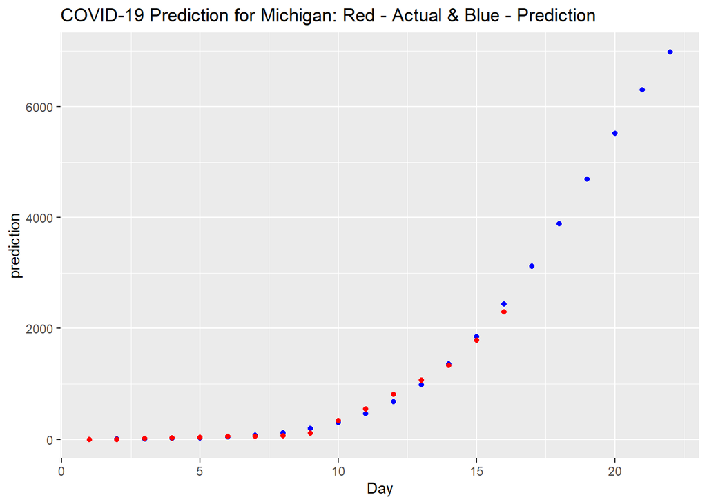

```r
#Plot the data
ggplot(d2[,1:2], aes(x = Day, y = prediction)) +
  geom_point(colour = "blue") +
  geom_point(na.omit(d2[,-2]), colour = "red", mapping = aes(x = Day, y = actual)) +
  ggtitle("COVID-19 Prediction for Michigan: Red - Actual & Blue - Prediction") +
  theme(legend.position = c(0, 1),legend.justification = c(0, 1))+
  scale_color_manual(values = c("blue","red"))
```

```r
# read data from a csv file
#-----------------------------------------------------------------------------------
#data <- us

# view data
#----------------------------------------------------------------------------------
#head(data)


# create samples from the data
#-----------------------------------------------------------------------------------
#samples = sample(1:104, size = 104*0.8)


## Predict model based on cases and days

# build an exponential regression model
#-----------------------------------------------------------------------------------
#model = lm(log(cases_cum) ~ Day + I(Day^2) , data = data[samples,])


# look at the summary of the model
#----------------------------------------------------------------------------------
#summary(model1)

# save model
#---------------------------------------------------------------------------------
#saveRDS(model, file = "Day_TotalCasesUS.RDS")

# predict for new data
#-------------------------------------------------------------------------------------
#prediction = exp(predict(model1, data.frame(Day = 1:109))

# put actual and predictions into a data frame
#-----------------------------------------------------------------------------------
#d2 = data.frame(Day = 1:109, floor(prediction), actual = c(data$cases_cum, rep(NA, 5)))
#d2

#Plot the data
#-------------------------------------------------------------------------------------
#3ggplot(d2[,1:2], aes(x = Day, y = prediction)) +
#  geom_point(colour = "blue") +
#  geom_point(na.omit(d2[,-2]), colour = "red", mapping = aes(x = Day, y = actual)) +
#  ggtitle("COVID-19 Prediction for Michigan: Red - Actual & Blue - Prediction") +
#  theme(plot.title = element_text(hjust = 0.5))
```